# Employee Attrition Prediction: Neural Network vs XGBoost Analysis

## Introduction to Data Science with Python - Summer School 2025

### Wrocław University of Science and Technology

```
Attrition Distribution:
Attrition
No     1233
Yes     237
Name: count, dtype: int64

Attrition Rate: 16.12%
```

## **Data Preprocessing**

### *Categorical and numerical features separation*

```
Categorical Features: 8
Numerical Features: 26
```

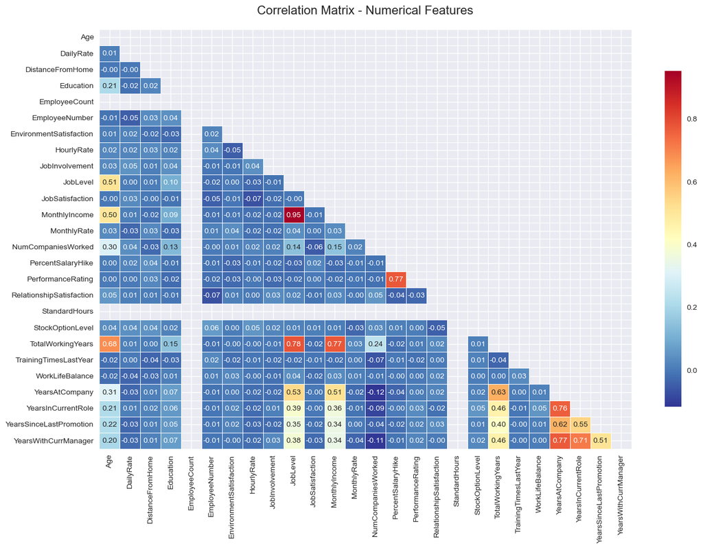

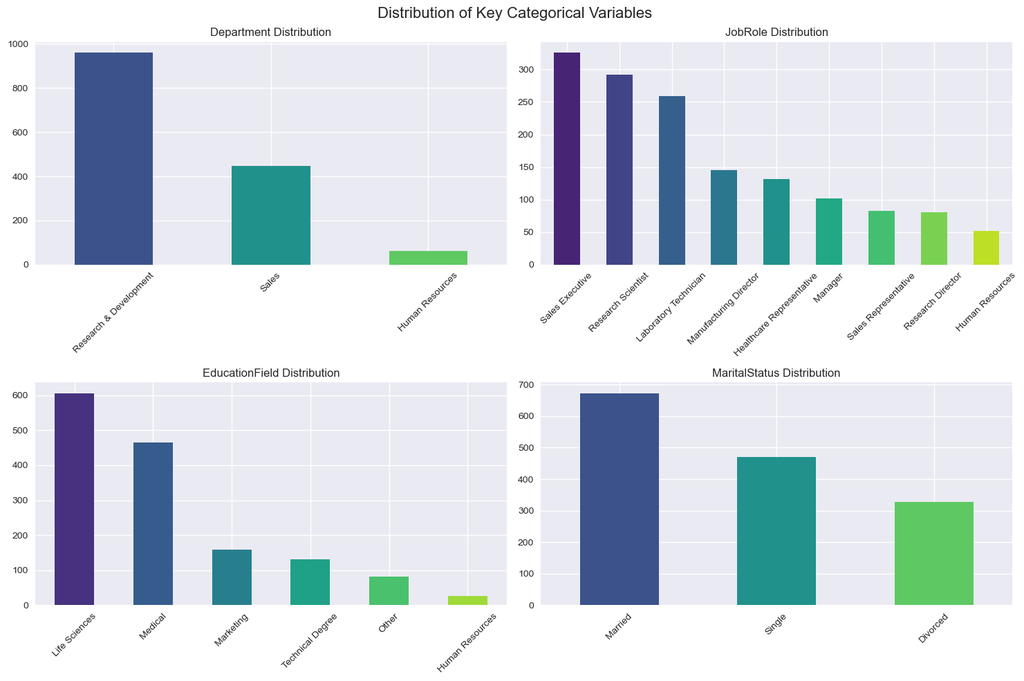

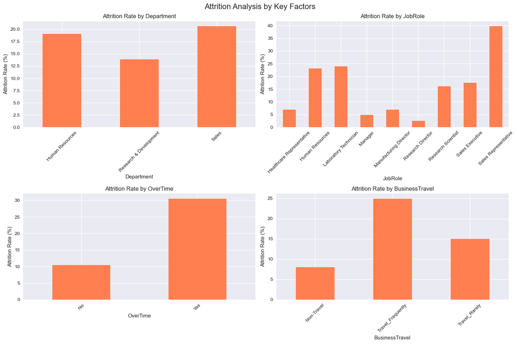

## **Data Preprocessing for Machine Learning**

## **Neural Network Model**

### *Deep learning approach with regularization*

```
Neural Network Architecture:
```

```
Model: "sequential_4"
```

```
┏━━━━━━━━━━━━━━━━━━━━━━━━━━━━━━━━━┳━━━━━━━━━━━━━━━━━━━━━━━━┳━━━━━━━━━━━━━━━┓
┃ Layer (type)                    ┃ Output Shape           ┃       Param # ┃
┡━━━━━━━━━━━━━━━━━━━━━━━━━━━━━━━━━╇━━━━━━━━━━━━━━━━━━━━━━━━╇━━━━━━━━━━━━━━━┩
│ dense_16 (Dense)                │ (None, 128)            │         6,144 │
├─────────────────────────────────┼────────────────────────┼───────────────┤
│ dropout_12 (Dropout)            │ (None, 128)            │             0 │
├─────────────────────────────────┼────────────────────────┼───────────────┤
│ dense_17 (Dense)                │ (None, 128)            │        16,512 │
├─────────────────────────────────┼────────────────────────┼───────────────┤
│ dropout_13 (Dropout)            │ (None, 128)            │             0 │
├─────────────────────────────────┼────────────────────────┼───────────────┤
│ dense_18 (Dense)                │ (None, 64)             │         8,256 │
├─────────────────────────────────┼────────────────────────┼───────────────┤
│ dropout_14 (Dropout)            │ (None, 64)             │             0 │
├─────────────────────────────────┼────────────────────────┼───────────────┤
│ dense_19 (Dense)                │ (None, 2)              │           130 │
└─────────────────────────────────┴────────────────────────┴───────────────┘
```

```
 Total params: 31,042 (121.26 KB)
```

```
 Trainable params: 31,042 (121.26 KB)
```

```
 Non-trainable params: 0 (0.00 B)
```

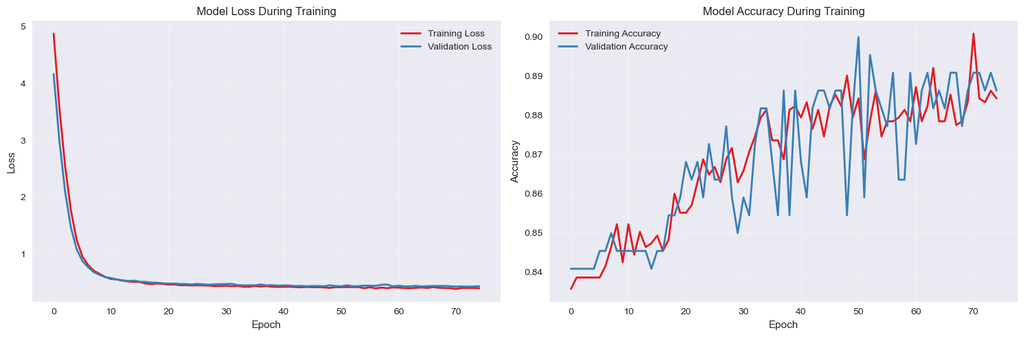

```
Neural Network Test Accuracy: 0.8778
```

## **XGBoost Model**

### *Gradient boosting approach*

```
XGBoost Test Accuracy: 0.8552
```

## **Model Comparison and Results**

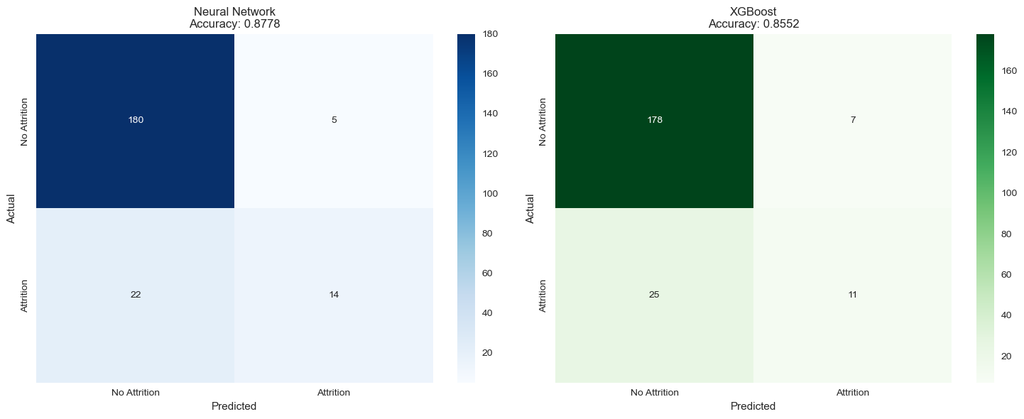

### Interpreting the confusion matrix for employee attrition

The confusion matrix provides a detailed breakdown of our model's performance by showing correct and incorrect predictions for each class.

|  |  | Predicted class |  |
| --- | --- | --- | --- |
|  |  | Predicted: will stay (0) | Predicted: will leave (1) |
| Actual class | Actual: stayed (0) | **True negatives (TN)** Correctly predicted employee will stay. *No unnecessary retention efforts* | **False positives (FP)** Incorrectly predicted employee will leave. *Type I error: wasted retention resources* |
|  | Actual: left (1) | **False negatives (FN)** Incorrectly predicted employee will stay. *Type II error: missed retention opportunity* | **True positives (TP)** Correctly predicted employee will leave. *Successful early identification* |

#### Key business insights for HR strategy:

- **True positives (TP)** are valuable: we correctly identify at-risk employees who can benefit from targeted retention strategies such as salary increases, promotions, or improved work-life balance.
- **False negatives (FN)** are COSTLY: these represent missed opportunities where valuable employees left unexpectedly. Minimizing FNs should be our priority as losing good employees is expensive.
- **False positives (FP)** have moderate cost: we might invest retention efforts in employees who weren't actually planning to leave, but this isn't necessarily wasteful if it improves overall satisfaction.
- **True negatives (TN)** represent efficient resource allocation: no unnecessary retention spending on stable employees.

#### Model selection considerations:

*In HR contexts, **RECALL** (ability to catch actual leavers) is often more important than **PRECISION** (accuracy of attrition predictions), since the cost of losing a valuable employee typically exceeds the cost of unnecessary retention efforts.*

## **Feature Importance Analysis**

### *Understanding what drives employee attrition*

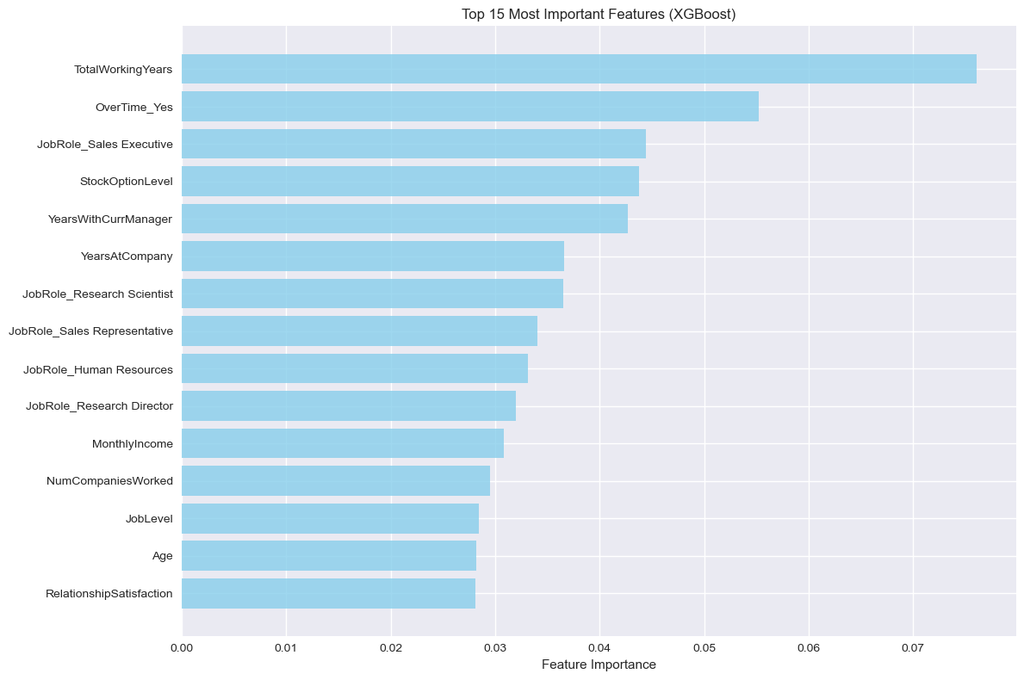

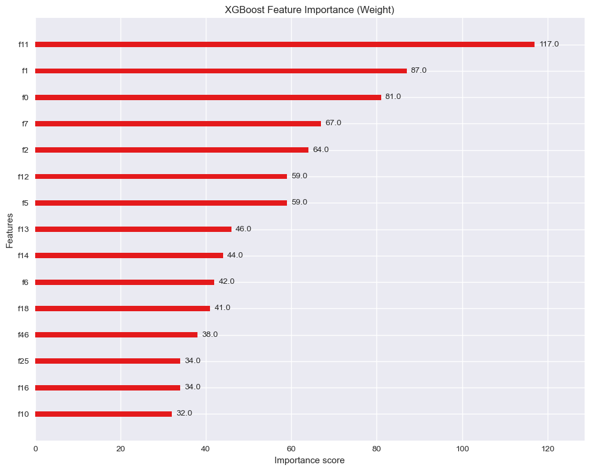

```python
# XGBoost built-in feature importance plot
fig, ax = plt.subplots(figsize=(10, 8))
plot_importance(xgb_model, ax=ax, importance_type='weight', max_num_features=15)
plt.title('XGBoost Feature Importance (Weight)')
plt.tight_layout()
plt.show()
```

## **Model Performance Summary**

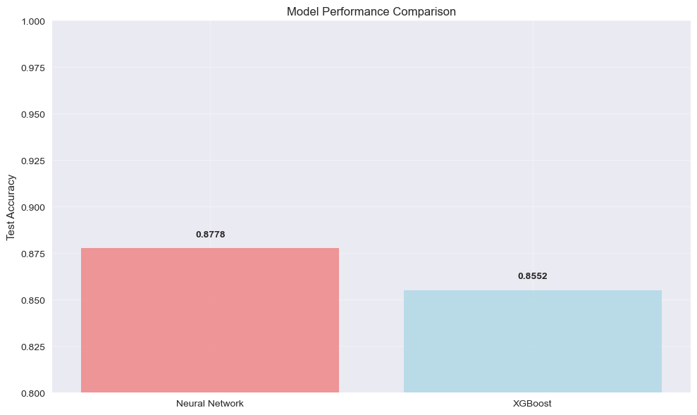

## **Key Insights and Conclusions**

### Key Findings:

**Business Implications:**

- Focus on work-life balance policies to reduce overtime requirements
- Review compensation structures, especially for younger employees
- Implement targeted retention strategies for high-risk job roles
- Regular job satisfaction surveys and improvement initiatives